# Statistical Programming Data Project II

Mohamed Diallo

03/30/2022

## Preface

This project will take an attempt at exploring the Olympics data set from **tidytuesday**. This data set was put together by Thomas Mock in 2018 with the help of the website (https://www.sports-reference.com). It is a collective work accomplished by an *Olympic history research* group of enthusiasts.

We begin importing the necessary libraries to load and manipulate the **Olympics** data-set, then we proceed with cleaning it up using the **tidytuesday** guidelines. The libraries we will be importing are *tidyverse* which will give us access to tools like *ggplot* in order to plot graphs. The library *readxl* will also be used to import the Olympics Excel <sup>**TM**</sup> file that we will be manipulating throughout the project. Extra libraries to help with aesthetics will also be initialized as well as the *here* library to assist with file location.

```r
library(tidyverse) #Core packages for data wrangling and visualization.
```

```r
library(readxl) #In order to read the Olympics data set as an excel table.
library(ggthemes) #To add more life to our graphs.
library(viridis)
library(fivethirtyeight)
library(hrbrthemes)
library(here)
library(extrafont)
extrafont::font_import()
```

```
## Importing fonts may take a few minutes, depending on the number of fonts and the speed of the system.
## Continue? [y/n]
```

```
## Exiting.
```

```r
file_path <- here("olympics.xlsx")
olymp <- read_excel(file_path) #
view(olymp)
```

## Introduction

Before we explore this data set about the Olympic games (OGs), knowing what it is in the first place and how it originated might give us more perspective. That being said, let’s rewind the clock to about 2,900 years back. Archaeological and literary evidence such as a series of bronze tripods suggests that Olympic games were held during these times. The year 776 B.C. marked the first official records of quadrennial Olympics. It is widely believed *Ancient* **Olympic Games (AOGs)**, as they are called nowadays, were held as part of a religious ritual in honor of Zeus, the Greek god of gods. Given the athletic nature of Greeks, and the purpose of honor behind the festival, there was no medal distributed for the winners of these games. However, they would return home as Heroes, believed to have been touched by the gods, and would be rewarded with a wreath of leaves. The games themselves were introduced when the *stadion* race (linear distance equal to 600 feet.) was won by a cook named Koroibos. In 394, the final AOG was hosted following the outlawing of pagan celebrations by Roman emperor, Theodosius I.

The year 490 however marked an important event that will be celebrated in the next OGs. This year, the “day-runner” Pheidippidis ran 240 kilometers from Marathon city to Sparta in order to enlist help following a Persian landing. Fast forward 1,406 years later and French educator and historian successfully orchestrates the beginning of the *New* **Olympic Games** which later included the standardized 42.195 km Marathon run in honor of Pheidippidis. This distance was measured as the exact distance between Windsor Castle and the finish line inside White City Stadium. A few more interesting events that happened in the history of the OGs are the two World Wars as the OGs were cancelled three times during these two periods. Our research paper will aim to find whether there is any meaningful statistical relationship between the number of medals won in Summer and in Winter OGs.

We could start by first getting a glimpse of the data we will be dealing with.

```r
glimpse(olymp)
```

```
## Rows: 271,116
## Columns: 15
## $ id     <dbl> 1, 2, 3, 4, 5, 5, 5, 5, 5, 5, 6, 6, 6, 6, 6, 6, 6, 6, 7, 7, 7, …
## $ name   <chr> "A Dijiang", "A Lamusi", "Gunnar Nielsen Aaby", "Edgar Lindenau…
## $ sex    <chr> "M", "M", "M", "M", "F", "F", "F", "F", "F", "F", "M", "M", "M"…
## $ age    <dbl> 24, 23, 24, 34, 21, 21, 25, 25, 27, 27, 31, 31, 31, 31, 33, 33,…
## $ height <dbl> 180, 170, NA, NA, 185, 185, 185, 185, 185, 185, 188, 188, 188, …
## $ weight <dbl> 80, 60, NA, NA, 82, 82, 82, 82, 82, 82, 75, 75, 75, 75, 75, 75,…
## $ team   <chr> "China", "China", "Denmark", "Denmark/Sweden", "Netherlands", "…
## $ noc    <chr> "CHN", "CHN", "DEN", "DEN", "NED", "NED", "NED", "NED", "NED", …
## $ games  <chr> "1992 Summer", "2012 Summer", "1920 Summer", "1900 Summer", "19…
## $ year   <dbl> 1992, 2012, 1920, 1900, 1988, 1988, 1992, 1992, 1994, 1994, 199…
## $ season <chr> "Summer", "Summer", "Summer", "Summer", "Winter", "Winter", "Wi…
## $ city   <chr> "Barcelona", "London", "Antwerpen", "Paris", "Calgary", "Calgar…
## $ sport  <chr> "Basketball", "Judo", "Football", "Tug-Of-War", "Speed Skating"…
## $ event  <chr> "Basketball Men's Basketball", "Judo Men's Extra-Lightweight", …
## $ medal  <chr> NA, NA, NA, "Gold", NA, NA, NA, NA, NA, NA, NA, NA, NA, NA, NA,…
```

```r
summary(olymp)
```

```
##        id             name               sex                 age
##  Min.   :     1   Length:271116      Length:271116      Min.   :10.00
##  1st Qu.: 34643   Class :character   Class :character   1st Qu.:21.00
##  Median : 68205   Mode  :character   Mode  :character   Median :24.00
##  Mean   : 68249                                         Mean   :25.56
##  3rd Qu.:102097                                         3rd Qu.:28.00
##  Max.   :135571                                         Max.   :97.00
##                                                         NA's   :9474
##      height          weight          team               noc
##  Min.   :127.0   Min.   : 25.0   Length:271116      Length:271116
##  1st Qu.:168.0   1st Qu.: 60.0   Class :character   Class :character
##  Median :175.0   Median : 70.0   Mode  :character   Mode  :character
##  Mean   :175.3   Mean   : 70.7
##  3rd Qu.:183.0   3rd Qu.: 79.0
##  Max.   :226.0   Max.   :214.0
##  NA's   :60171   NA's   :62875
##     games                year         season              city
##  Length:271116      Min.   :1896   Length:271116      Length:271116
##  Class :character   1st Qu.:1960   Class :character   Class :character
##  Mode  :character   Median :1988   Mode  :character   Mode  :character
##                     Mean   :1978
##                     3rd Qu.:2002
##                     Max.   :2016
##
##     sport              event              medal
##  Length:271116      Length:271116      Length:271116
##  Class :character   Class :character   Class :character
##  Mode  :character   Mode  :character   Mode  :character
##
##
##
##
```

## Data Wrangling

```r
yearly_athletes <- olymp %>%
  group_by(year, season) %>%
  summarise(
    athletes = length(unique(id)),
    nations = length(unique(noc)),
    events = length(unique(event))
  )
view(yearly_athletes)
```

Next, we plot a faceted dot-plot of the number of athletes per year according to the season.

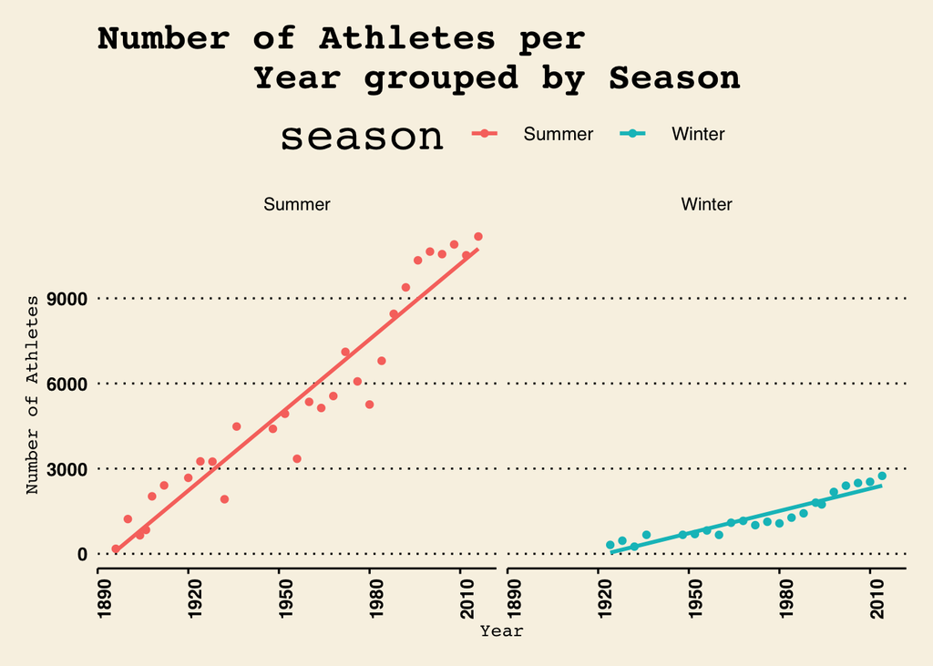

```r
ath_per_year <- yearly_athletes %>%
  ggplot(aes(x = year, y = athletes, stat = "identity", color = season)) +
  geom_point() +
  geom_smooth(method = "lm", se = FALSE) +
  facet_wrap(~season) +
   theme_wsj() +
  theme(axis.text.x = element_text(angle = 90, size = 10),
                      axis.text.y = element_text(size = 10),
                      axis.title = element_text(size = 10),
                      plot.title = element_text(size = 20),
                      legend.title = element_text(size = 25),
                      legend.text = element_text(size = 10)) +
  labs(x = "Year", y = "Number of Athletes", title = "Number of Athletes per
       Year grouped by Season")

ath_per_year
```

```r
summer_aths <- yearly_athletes %>% filter(season == 'Summer')
summer_aths
```

```
## # A tibble: 29 × 5
## # Groups:   year [29]
##     year season athletes nations events
##    <dbl> <chr>     <int>   <int>  <int>
##  1  1896 Summer      176      12     43
##  2  1900 Summer     1224      31     90
##  3  1904 Summer      650      15     95
##  4  1906 Summer      841      21     74
##  5  1908 Summer     2024      22    109
##  6  1912 Summer     2409      29    107
##  7  1920 Summer     2676      29    158
##  8  1924 Summer     3256      45    131
##  9  1928 Summer     3247      46    122
## 10  1932 Summer     1922      47    131
## # … with 19 more rows
```

```r
mean_summeraths <- mean(summer_aths$athletes)
mean_summeraths
```

```
## [1] 5477.897
```

```r
winter_aths <- yearly_athletes %>% filter(season == 'Winter')
winter_aths
```

```
## # A tibble: 22 × 5
## # Groups:   year [22]
##     year season athletes nations events
##    <dbl> <chr>     <int>   <int>  <int>
##  1  1924 Winter      313      19     17
##  2  1928 Winter      461      25     14
##  3  1932 Winter      252      17     14
##  4  1936 Winter      668      28     17
##  5  1948 Winter      668      28     22
##  6  1952 Winter      694      30     22
##  7  1956 Winter      821      32     24
##  8  1960 Winter      665      30     27
##  9  1964 Winter     1094      36     34
## 10  1968 Winter     1160      37     35
## # … with 12 more rows
```

```r
mean_winteraths <- mean(winter_aths$athletes)
mean_winteraths
```

```
## [1] 1299.682
```

```r
median_summeraths <- median(summer_aths$athletes)

median_winteraths <- median(winter_aths$athletes)

print(paste("The median number of athletes present in Summer Olympic games is:", median_summeraths))
```

```
## [1] "The median number of athletes present in Summer Olympic games is: 5137"
```

```r
print(paste("The median number of athletes present in Winter Olympic games is:", median_winteraths))
```

```
## [1] "The median number of athletes present in Winter Olympic games is: 1111"
```

We can see that the mean number of athletes present throughout the summer games is 5477.897 whilst the mean number of athletes present in the winter games is 1299.682. This in theory means we could hypothesize that the gold medals won in summer games affect the total number of medals won more than those in winter games. We will be verifying this assumption later down the project.

Next, since the mark for honor has been symbolized by medals in recent OGs, let us extract the number of medals won by athletes for each season every year. Seeing as summer games started earlier than winter ones, we will filter out all of the OGs hosted before 1924 so that we obtain the same number of winter and summer games. This will ensure better uniformity of our data.

```r
arranged_yearly <- olymp %>%
  arrange(year, season, sex, medal) %>%
  mutate(got_medal= if_else(.$medal == is.na(medal), 0, 1))

view(arranged_yearly)

medal_per_szn <- arranged_yearly %>%
  group_by(year, season, sex) %>%
  count(got_medal) %>%
  filter(year >= 1924 & got_medal != is.na(got_medal)) %>%
  ungroup() %>%
  summarise(year, season, sex, n)

view(medal_per_szn)
```

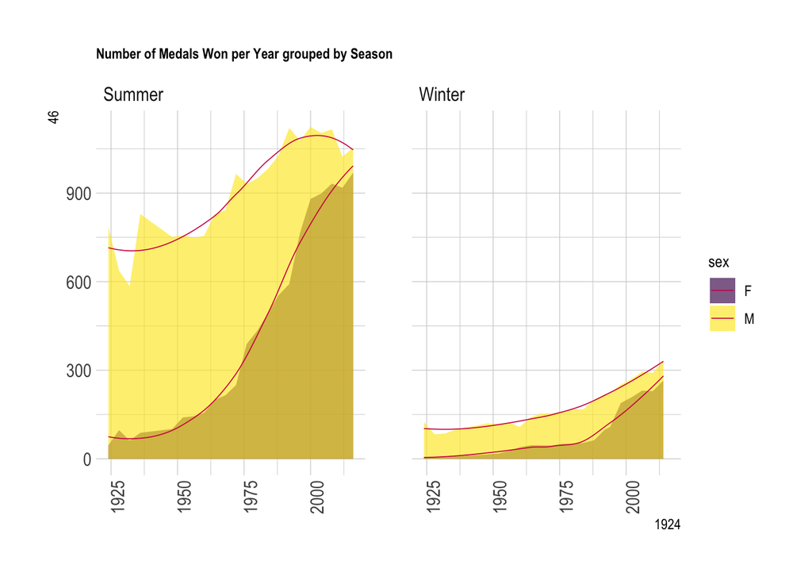

```r
medal_per_szn %>% ggplot(aes(x = year, y = n, fill = sex)) +
  scale_x_continuous(medal_per_szn$year) +
  scale_y_continuous(medal_per_szn$n) +
  scale_fill_viridis(discrete = T) +
  geom_area(position = 'dodge', alpha = 0.65) +
  geom_smooth(method = "loess", se = FALSE, color = "#D11D53", size = 0.3) +
  facet_wrap(~season) +
  theme_ipsum() +
  theme(axis.text.x = element_text(angle = 90),
        plot.title = element_text(size = 9),
        legend.title = element_text(size = 10)) +
  ggtitle("Number of Medals Won per Year grouped by Season") +
  ylab("Number of Medals") +
  labs(x = "Year", y = "Number of Medals",
       title = "Number of Medals Won per Year grouped by Season")
```

We can see that the number of medals won per year have been steadily increasing both in summer and winter games. This seemingly goes in accordance with the increase with the number of athletes per year for both winter and summer OGs. Summer games yield the higher number of medals but it seems as though these have been in decline in recent years whilst the winter games number of medals has been on a steady increase. Next, we could run an ANOVA test to verify whether the season in which an OG was hosted can explain the number of medals won in the OGs. In other words, we will find out whether there is, statistically speaking, a significant difference in season versus number of medals won.

```r
ref_mps <- medal_per_szn %>%
  rename(medal_count = n)
```

```r
ref_mps <- ref_mps %>%
  select(year, season, medal_count)
view(ref_mps)
ref_mps_aov <- aov(medal_count ~ season, data = ref_mps)
summary(ref_mps_aov)
```

```
##             Df  Sum Sq Mean Sq F value   Pr(>F)
## season       1 6340896 6340896   92.96 2.43e-15 ***
## Residuals   86 5866338   68213
## ---
## Signif. codes:  0 '***' 0.001 '**' 0.01 '*' 0.05 '.' 0.1 ' ' 1
```

Finally, since we can safely hypothesize that the season in which an OG was hosted can explain for the number of medals obtained in those games, one more interesting piece of information we could pull from this data-set is the top ten countries with the highest number of medals, in other words, the ones that bring the bag home. We could also plot a bar chart of the number of medals won in winter compared to summer.

```r
medal_per_noc <- arranged_yearly %>%
  filter(got_medal != is.na(got_medal)) %>%
  summarise(noc, got_medal) %>%
  group_by(noc) %>%
  count() %>%
  ungroup() %>%
  top_n(10)
view(medal_per_noc)
```

```r
medal_per_seas <- arranged_yearly %>%
  filter(got_medal != is.na(got_medal)) %>%
  summarise(season, got_medal) %>%
  group_by(season) %>%
  count() %>%
  rename(Total_Medals = n) %>%
  ungroup()


view(medal_per_seas)
```

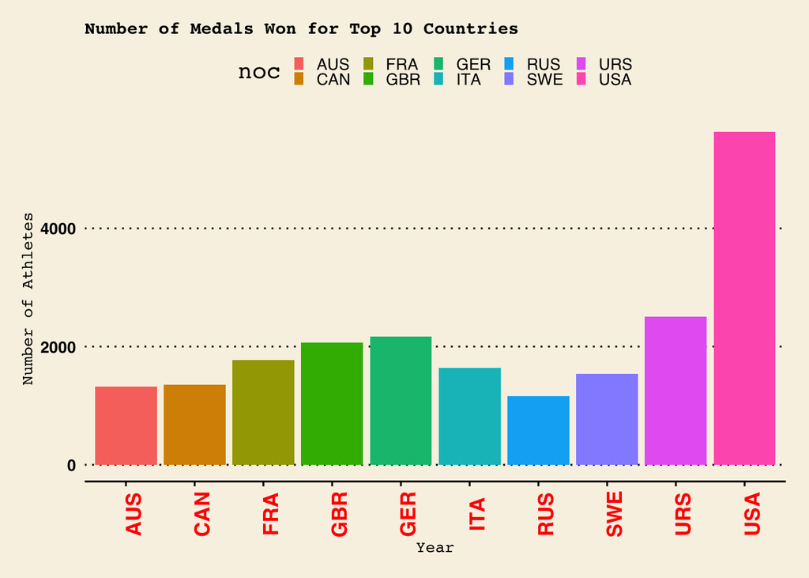

```r
medal_per_noc %>% ggplot(aes(x = noc, y = n, fill = noc)) +
  geom_col() +
  theme_wsj() +
  scale_colour_economist() +
  theme(axis.text.x = element_text(face = "bold",
                                   angle = 90,
                                   colour = "red",
                                   size = 13),
                      axis.text.y = element_text(size = 10),
                      axis.title = element_text(size = 10),
                      plot.title = element_text(size = 11),
                      legend.title = element_text(size = 15),
                      legend.text = element_text(size = 10),
        legend.key.size = unit(0.5, "line")) +
  labs( color = "Country", x = "Year", y = "Number of Athletes", title = "Number of Medals Won for Top 10 Countries")
```

```r
medal_per_noc
```

```
## # A tibble: 10 × 2
##    noc       n
##    <chr> <int>
##  1 AUS    1320
##  2 CAN    1352
##  3 FRA    1777
##  4 GBR    2068
##  5 GER    2165
##  6 ITA    1637
##  7 RUS    1165
##  8 SWE    1536
##  9 URS    2503
## 10 USA    5637
```

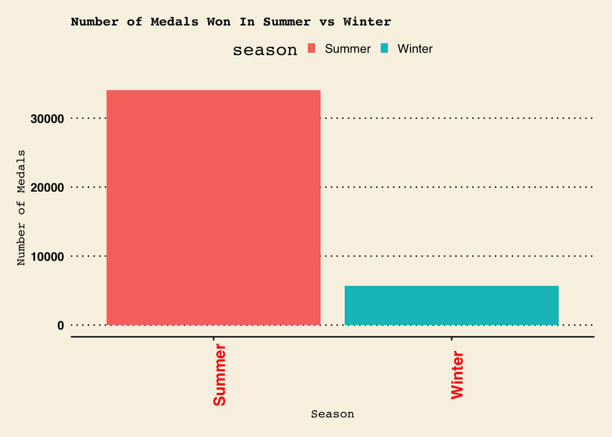

```r
medal_per_seas %>% ggplot(aes(x = season, y = Total_Medals, fill = season)) +
  geom_col() +
  theme_wsj() +
  scale_colour_economist() +
  theme(axis.text.x = element_text(face = "bold",
                                   angle = 90,
                                   colour = "red",
                                   size = 13),
                      axis.text.y = element_text(size = 10),
                      axis.title = element_text(size = 10),
                      plot.title = element_text(size = 11),
                      legend.title = element_text(size = 15),
                      legend.text = element_text(size = 10),
        legend.key.size = unit(0.5, "line")) +
  labs( color = "Country", x = "Season",
        y = "Number of Medals",
        title = "Number of Medals Won In Summer vs Winter")
```

```r
medal_per_seas
```

```
## # A tibble: 2 × 2
##   season Total_Medals
##   <chr>         <int>
## 1 Summer        34088
## 2 Winter         5695
```

## Conclusion

In summary, we can come to the conclusion that the season in which a game is hosted can be used to statistically explain the number of medals won in those OGs. A better way to prove this would have been to add a boxplot showing the spread of medals per season and the mean number of medals won, this would however require us to include the year as another observational variable whereas we only wanted to focus on the medals by season. The OGs have had a long history for sure but the data present in this data-set tell much more as I am confident that we have barely scratched its surface.